# UD5 N01

## Regresión logística

Vamos a ver cómo se ajustan los modelos de regresión logística y cómo se interpretan las salidas.

Cargamos datos de enfermedades cardiovasculares en Sudáfrica. La columna “chd” indica si la persona padece con un 1 y con un 0 si no la padece.

```r
# install.packages("ElemStatLearn")
library(ElemStatLearn)
data("SAheart")
help(SAheart)
head(SAheart)
```

|  | sbp | tobacco | ldl | adiposity | famhist | typea | obesity | alcohol | age | chd |
| --- | --- | --- | --- | --- | --- | --- | --- | --- | --- | --- |
| 1 | 160 | 12.00 | 5.73 | 23.11 | Present | 49 | 25.30 | 97.20 | 52 | 1 |
| 2 | 144 | 0.01 | 4.41 | 28.61 | Absent | 55 | 28.87 | 2.06 | 63 | 1 |
| 3 | 118 | 0.08 | 3.48 | 32.28 | Present | 52 | 29.14 | 3.81 | 46 | 0 |
| 4 | 170 | 7.50 | 6.41 | 38.03 | Present | 51 | 31.99 | 24.26 | 58 | 1 |
| 5 | 134 | 13.60 | 3.50 | 27.78 | Present | 60 | 25.99 | 57.34 | 49 | 1 |
| 6 | 132 | 6.20 | 6.47 | 36.21 | Present | 62 | 30.77 | 14.14 | 45 | 0 |

```r
#la variable categórica a relacionar es chd
str(SAheart)
```

```
'data.frame':   462 obs. of  10 variables:
 $ sbp      : int  160 144 118 170 134 132 142 114 114 132 ...
 $ tobacco  : num  12 0.01 0.08 7.5 13.6 6.2 4.05 4.08 0 0 ...
 $ ldl      : num  5.73 4.41 3.48 6.41 3.5 6.47 3.38 4.59 3.83 5.8 ...
 $ adiposity: num  23.1 28.6 32.3 38 27.8 ...
 $ famhist  : Factor w/ 2 levels "Absent","Present": 2 1 2 2 2 2 1 2 2 2 ...
 $ typea    : int  49 55 52 51 60 62 59 62 49 69 ...
 $ obesity  : num  25.3 28.9 29.1 32 26 ...
 $ alcohol  : num  97.2 2.06 3.81 24.26 57.34 ...
 $ age      : int  52 63 46 58 49 45 38 58 29 53 ...
 $ chd      : int  1 1 0 1 1 0 0 1 0 1 ...
```

La función que realiza la regresión logística es `glm`, creamos un modelo de regresión logística sobre la variable “tobacco”

```r
help("glm")
mod <- glm(chd~tobacco, data=SAheart, family=binomial)
mod$coefficients
```

```
(Intercept)     tobacco
 -1.1894300   0.1452696
```

```r
summary(mod)
```

```
Call:
glm(formula = chd ~ tobacco, family = binomial, data = SAheart)

Deviance Residuals:
    Min       1Q   Median       3Q      Max
-1.9397  -0.8467  -0.7290   1.1997   1.7060

Coefficients:
            Estimate Std. Error z value Pr(>|z|)
(Intercept) -1.18943    0.13900  -8.557  < 2e-16 ***
tobacco      0.14527    0.02476   5.866 4.46e-09 ***
---
Signif. codes:  0 ‘***’ 0.001 ‘**’ 0.01 ‘*’ 0.05 ‘.’ 0.1 ‘ ’ 1

(Dispersion parameter for binomial family taken to be 1)

    Null deviance: 596.11  on 461  degrees of freedom
Residual deviance: 554.65  on 460  degrees of freedom
AIC: 558.65

Number of Fisher Scoring iterations: 4
```

Pintamos la variable “chd” frente a “tobacco” para observar la propensión de estar enfermo respecto al consumo de tabaco. Representamos la sigmoide resultante respecto a la variable “tobacco”

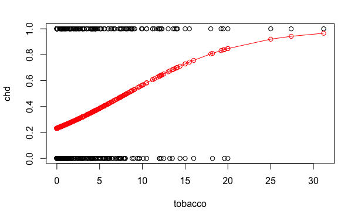

```r
plot(chd ~ tobacco, data=SAheart)
lines(sort(SAheart$tobacco), mod$fitted[order(SAheart$tobacco)], type="o", col="red")
```

Se observa que si bien mayor cantidad de tabaco incide en mayor probabilidad de tener chd, las clases no están realmente bien separadas por la variable “tobacco”

Creamos un modelo sobre todas las variables, observamos que las variables más relevantes son “famhistPresent”, “tobacco”, “ldl”, “typea” y “age”

```r
mod <- glm(chd~., data=SAheart, family=binomial)
mod$coefficients
```

```
   (Intercept)            sbp        tobacco            ldl      adiposity
 -6.1507208650   0.0065040171   0.0793764457   0.1739238981   0.0185865682
famhistPresent          typea        obesity        alcohol            age
  0.9253704194   0.0395950250  -0.0629098693   0.0001216624   0.0452253496
```

```r
summary(mod)
```

```
Call:
glm(formula = chd ~ ., family = binomial, data = SAheart)

Deviance Residuals:
    Min       1Q   Median       3Q      Max
-1.7781  -0.8213  -0.4387   0.8889   2.5435

Coefficients:
                 Estimate Std. Error z value Pr(>|z|)
(Intercept)    -6.1507209  1.3082600  -4.701 2.58e-06 ***
sbp             0.0065040  0.0057304   1.135 0.256374
tobacco         0.0793764  0.0266028   2.984 0.002847 **
ldl             0.1739239  0.0596617   2.915 0.003555 **
adiposity       0.0185866  0.0292894   0.635 0.525700
famhistPresent  0.9253704  0.2278940   4.061 4.90e-05 ***
typea           0.0395950  0.0123202   3.214 0.001310 **
obesity        -0.0629099  0.0442477  -1.422 0.155095
alcohol         0.0001217  0.0044832   0.027 0.978350
age             0.0452253  0.0121298   3.728 0.000193 ***
---
Signif. codes:  0 ‘***’ 0.001 ‘**’ 0.01 ‘*’ 0.05 ‘.’ 0.1 ‘ ’ 1

(Dispersion parameter for binomial family taken to be 1)

    Null deviance: 596.11  on 461  degrees of freedom
Residual deviance: 472.14  on 452  degrees of freedom
AIC: 492.14

Number of Fisher Scoring iterations: 5
```

```r
#calcula las predicciones sobre todos las instancias
y_pred <- predict(mod, subset(SAheart,select = -chd ), type="response")
head(y_pred)
```

```
        1         2         3         4         5         6
0.7121829 0.3310109 0.2809570 0.7171233 0.6930608 0.6176621
```

La interpretación de los coeficientes: mientras mayor sean más probabilidad aportan de que tenga chd y mientras menor valor tengan menor probabilidad de que tengan chd

```r
summary(mod)
```

```
Call:
glm(formula = chd ~ ., family = binomial, data = SAheart)

Deviance Residuals:
    Min       1Q   Median       3Q      Max
-1.7781  -0.8213  -0.4387   0.8889   2.5435

Coefficients:
                 Estimate Std. Error z value Pr(>|z|)
(Intercept)    -6.1507209  1.3082600  -4.701 2.58e-06 ***
sbp             0.0065040  0.0057304   1.135 0.256374
tobacco         0.0793764  0.0266028   2.984 0.002847 **
ldl             0.1739239  0.0596617   2.915 0.003555 **
adiposity       0.0185866  0.0292894   0.635 0.525700
famhistPresent  0.9253704  0.2278940   4.061 4.90e-05 ***
typea           0.0395950  0.0123202   3.214 0.001310 **
obesity        -0.0629099  0.0442477  -1.422 0.155095
alcohol         0.0001217  0.0044832   0.027 0.978350
age             0.0452253  0.0121298   3.728 0.000193 ***
---
Signif. codes:  0 ‘***’ 0.001 ‘**’ 0.01 ‘*’ 0.05 ‘.’ 0.1 ‘ ’ 1

(Dispersion parameter for binomial family taken to be 1)

    Null deviance: 596.11  on 461  degrees of freedom
Residual deviance: 472.14  on 452  degrees of freedom
AIC: 492.14

Number of Fisher Scoring iterations: 5
```

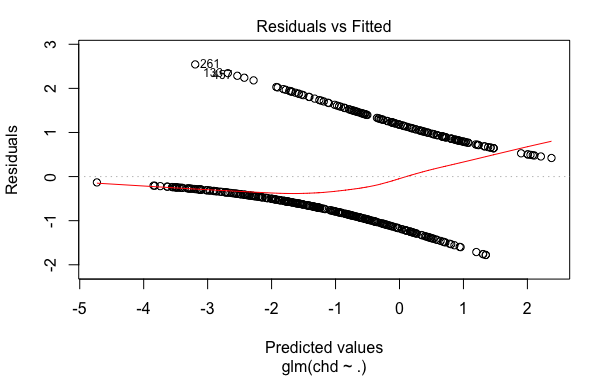

```r
plot(mod,which=1)
```

Vemos aquí la explicación con detalle: https://freakonometrics.hypotheses.org/8210

Buscamos el mejor modelo

```r
fit1 <- glm(chd~., data=SAheart, family=binomial)
fit0 <- glm(chd~1, data=SAheart, family=binomial)
library(MASS)
step <-stepAIC(fit0,direction="both",scope=list(upper=fit1,lower=fit0))
```

```
Start:  AIC=598.11
chd ~ 1

            Df Deviance    AIC
+ age        1   525.56 529.56
+ tobacco    1   554.65 558.65
+ famhist    1   561.89 565.89
+ ldl        1   564.28 568.28
+ adiposity  1   565.05 569.05
+ sbp        1   579.32 583.32
+ typea      1   591.12 595.12
+ obesity    1   591.53 595.53
<none>           596.11 598.11
+ alcohol    1   594.35 598.35

Step:  AIC=529.56
chd ~ age

            Df Deviance    AIC
+ famhist    1   506.66 512.66
+ ldl        1   512.48 518.48
+ typea      1   513.04 519.04
+ tobacco    1   515.39 521.39
<none>           525.56 529.56
+ sbp        1   524.44 530.44
+ adiposity  1   524.78 530.78
+ alcohol    1   524.89 530.89
+ obesity    1   525.55 531.55
- age        1   596.11 598.11

Step:  AIC=512.66
chd ~ age + famhist

            Df Deviance    AIC
+ tobacco    1   495.39 503.39
+ typea      1   495.64 503.64
+ ldl        1   496.18 504.18
<none>           506.66 512.66
+ sbp        1   505.24 513.24
+ adiposity  1   506.22 514.22
```

[output cut: 34 more lines]

```

Step:  AIC=487.69
chd ~ age + famhist + tobacco + typea + ldl

            Df Deviance    AIC
<none>           475.69 487.69
+ obesity    1   473.98 487.98
+ sbp        1   474.65 488.65
+ adiposity  1   475.44 489.44
+ alcohol    1   475.65 489.65
- ldl        1   484.71 494.71
- typea      1   485.44 495.44
- tobacco    1   486.03 496.03
- famhist    1   492.09 502.09
- age        1   502.38 512.38
```

```r
mod <- glm(chd ~ age + famhist + tobacco + typea + ldl, data=SAheart, family=binomial)
mod$coefficients
```

```
   (Intercept)            age famhistPresent        tobacco          typea
   -6.44644451     0.05046038     0.90817526     0.08037533     0.03711521
           ldl
    0.16199164
```

```r
step$residuals
```

[output not shown]

[output cut: 61 more lines]

[output not shown]

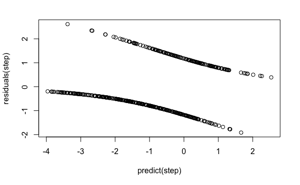

```r
plot(predict(step),residuals(step))
```

```r
coefficients(step)
```

```
   (Intercept)            age famhistPresent        tobacco          typea
   -6.44644451     0.05046038     0.90817526     0.08037533     0.03711521
           ldl
    0.16199164
```

```r
# predecimos 1 si la probabilidad es mayor que 0.5 y 0 si es menor que 0.5 y comparamos
y_pred <- predict(step)>.5
head(y_pred)
```

```
    1     2     3     4     5     6
 TRUE FALSE FALSE  TRUE  TRUE  TRUE
```

```r
head(SAheart$chd)
```

```
[1] 1 1 0 1 1 0
```

```r
y_pred <- as.numeric(predict(mod, subset(SAheart,select = -chd ), type="response")>.5)
y <- as.numeric(SAheart$chd)
# install.packages(c("e1071", "caret", "e1071")
library(caret)
library(ggplot2)
library(lattice)
library(e1071)
confusionMatrix(y, y_pred, mode="everything")
```

[output not shown]

Observamos cómo influyen los factores en la enfermedad a través de los coeficientes y los *log odds*

```r
coef(mod)
```

```
   (Intercept)            age famhistPresent        tobacco          typea
   -6.44644451     0.05046038     0.90817526     0.08037533     0.03711521
           ldl
    0.16199164
```

```r
exp(coef(mod))
```

```
   (Intercept)            age famhistPresent        tobacco          typea
   0.001586152    1.051755195    2.479793436    1.083693731    1.037812583
           ldl
   1.175850406
```

Obtenemos un intervalo de confianza para los valores de los coeficientes:

```r
exp(confint(mod))
```

```
                      2.5 %      97.5 %
(Intercept)    0.0002431694 0.009046052
age            1.0313449715 1.073545765
famhistPresent 1.5965570204 3.873331440
tobacco        1.0313670740 1.141906910
typea          1.0137460457 1.063378023
ldl            1.0574557051 1.312726646
```